# MI-PAA, Úloha 1: Řešení problému batohu metodou hrubé síly a jednoduchou heuristikou

### Relativní chyby při výpočtu heuristikou

Jednoduchá heuristika, jako ta, která byla použita v této úloze, s největší pravděpodobností nebude schopná určit optimální řešení v každé instanci.

Relativní chybou lze určit úspěšnost heuristického výpočtu vůči exaktního výpočtu hrubou silou. Relativní chyby jsou uvedeny v procentech.

```python
pd.options.mode.chained_assignment = None

# Výpočet absolutních a relativních chyb u každého výpočtu heuristickou metodou
heuristic_data = data[data['method'] == 'Heuristic']
heuristic_data['error'] = heuristic_data['optimal_price'] - heuristic_data['price']
heuristic_data['relative_error_%'] = (heuristic_data['error'] / heuristic_data['optimal_price']) * 100

heuristic_data[['knap_id', 'item_count', 'optimal_price', 'price', 'error', 'relative_error_%']]
```

|  | knap_id | item_count | optimal_price | price | error | relative_error_% |
| --- | --- | --- | --- | --- | --- | --- |
| 1 | 9000 | 4 | 473 | 415 | 58 | 12.262156 |
| 3 | 9001 | 4 | 326 | 326 | 0 | 0.000000 |
| 5 | 9002 | 4 | 196 | 196 | 0 | 0.000000 |
| 7 | 9003 | 4 | 545 | 437 | 108 | 19.816514 |
| 9 | 9004 | 4 | 243 | 243 | 0 | 0.000000 |
| ... | ... | ... | ... | ... | ... | ... |
| 695 | 9347 | 27 | 2545 | 1049 | 1496 | 58.781925 |
| 697 | 9348 | 27 | 2846 | 1563 | 1283 | 45.080815 |
| 699 | 9349 | 27 | 3019 | 1377 | 1642 | 54.388870 |
| 701 | 9350 | 30 | 2875 | 964 | 1911 | 66.469565 |
| 703 | 9351 | 30 | 3327 | 1566 | 1761 | 52.930568 |

352 rows × 6 columns

```python
# Zpracování relativních chyb pro každý počet předmětů jednotlivě
mean_vals = {}
rows_cnt = {}
max_vals = {}

for index, row in heuristic_data.iterrows():
    out_id = row['item_count']
    error = row['relative_error_%']

    mean_vals[out_id] = mean_vals[out_id] + error if out_id in mean_vals else error
    rows_cnt[out_id] = rows_cnt[out_id] + 1 if out_id in rows_cnt else 1
    if out_id in max_vals:
        max_vals[out_id] = error if error > max_vals[out_id] else max_vals[out_id]
    else:
        max_vals[out_id] = error

for index, row in mean_vals.items():
    mean_vals[index] = row / rows_cnt[index]

relative_errors = pd.DataFrame({'avg_rel_error_%': mean_vals, 'max_rel_error_%': max_vals})

# Výpis průměru a maxima relativní chyby pro každý počet předmětů
relative_errors
```

|  | avg_rel_error_% | max_rel_error_% |
| --- | --- | --- |
| 4 | 9.125447 | 72.727273 |
| 10 | 26.621721 | 61.094819 |
| 15 | 27.724194 | 56.969697 |
| 20 | 45.451606 | 69.780220 |
| 22 | 50.922441 | 71.792657 |
| 25 | 51.913568 | 69.696970 |
| 27 | 49.994587 | 63.565062 |
| 30 | 59.700067 | 66.469565 |

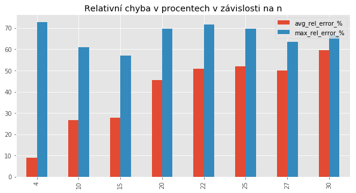

```python
relative_errors.plot(
    title = 'Relativní chyba v procentech v závislosti na n',
    kind = 'bar',
)
```

```python
# Statistiky pro všechny počty předmětů dohromady
relative_errors.describe()[1:][['avg_rel_error_%']]
```

|  | avg_rel_error_% |
| --- | --- |
| mean | 40.181704 |
| std | 17.161356 |
| min | 9.125447 |
| 25% | 27.448576 |
| 50% | 47.723097 |
| 75% | 51.170223 |
| max | 59.700067 |

Na grafu lze pozorovat mírně vzrůstající trend průměrné relativní chyby při vzrůstajícím počtu předmětů. O lineární vzrůst však s největší pravděpodobností nepůjde a dalo by se spíše předpokládat, že hodnota průměrné chyby se limitně blíží k 50%. Lepší odhad by poskytl větší vzorek dat, pro větší počty předmětů.

Grafická reprezentace maximální relativní chyby nenese žádnou podstatnou informaci (z grafu nelze vyčíst nic použitelného pro závěr).

## Závěr

Prvotní předpoklad, že výpočet problému batohu pomocí jednoduché heuristiky bude řádově rychlejší, než výpočet hrubou silou, se potvrdil. Na datech lze vidět důsledky složitosti algoritmu `O(2^n)`.

Průměrná relativní chyba při řešení pomocí heuristiky se ukázala, že je spíše vyšší a tak se podstatně liší i kvalita řešení obou metod. Metoda řešení pomocí heuristiky totiž vrací spíše méně kvalitní řešení (často `<50%`).

Lze tvrdit, že výpočet heuristikou se vyplácí až v bodě, kdy relativní chyba řešení nevzrůstá, protože víme, že časová náročnost řešení hrubou silou bude vzrůstat zaručeně vždy. K potvrzení tohoto tvrzení by byly vhodné další vzorky dat pro vyšší počty předmětů, aby mohl být trend relativní chyby jednoznačně určitelný. Výpočet dalších vzorků dat je však časově náročný a přesahuje hranice této úlohy.

Zdrojové soubory úlohy lze najít na GitHubu. Link je uveden v hlavičce zprávy.